# Agrupamento dos Resumos dos Trabalhos Apresntados na $8^{a}$ SIEPE

Jayme Gomes dos Santos Junior Jhenifer Caetano Veloso

## Introdução

A SIEPE (Semana Integrada de Ensino, Pesquisa e Extensão) é um evento anual da Universidade Federal do Paraná (UFPR) que integra o Ensino, a Pesquisa e a Extensão com a finalidade de promover e estimular a interação entre docentes, estudantes de graduação, educação profissional, ensino médio e pós-graduação, servidores técnicos, servidoras técnicas e comunidade em geral. O objetivo da SIEPE é divulgar trabalhos institucionais orientados por docentes da UFPR nas atividades de Ensino, Pesquisa e Extensão. Os trabalhos dos programas/projetos da UFPR são divididos por encontros, sendo eles: Encontro das Atividades Formativas (ENAF), Evento de Iniciação Científica (EVINCI), Evento de Iniciação em Desenvolvimento Tecnológico e Inovação (EINTI) e Encontro de Extensão e Cultura (ENEC).  
Para este trabalho foram considerados os resumos dos trabalhos apresentados no ENAF, o qual engloba os programas/projetos do Licenciar, PET, PIBID, PVA, PET - Saúde, PID (monitoria), além de trabalhos orientados em Monografias/TCC, disciplinas de Introdução à Pesquisa, Estágios, Recursos Educacionais Abertos (REA), projetos de Ações Afirmativas. No do ENAF os trabalhos são divididos por áreas temáticas, as quais são: comunicação, cultura, educação, trabalho, saúde, direitos humanos e justiça, meio ambiente, e tecnologia e produção.  
Pensando na quantidade de perticipantes que os programas possuem, é de se esperar que haja uma alta quantidade de resumos inscritos. E ainda, como os trabalhos são agrupados? São agrupados de maneira correta? Isto posto, o objetivo do presente trabalho é agrupar, meio de uma técnica de análise de texto, os resumos dos projetos apresentados na SIEPE.  
Felizmente em R, linguagem e ambiente para computação estatística e gráfica com a qual estou ambientada, existem pacotes (conjunto de funções) já implementadas que tornam a realização deste trabalho mais simples. Aqui, fez-se uso do pacotes:

```r
library(pdftools)
library(tm)
library(latticeExtra)
library(wordcloud)
library(dendextend)
```

## Conjunto de Dados

O conjunto de dados analisados referem-se aos resumos dos projetos apresentados na $8^{ª}$ SIEPE / $15^{°}$ ENAF, realizada entre os dias 03 e 07 de outubro de 2016. A extração dos dados foi feita manualmente, pois o sítio eletrônico onde o site está hospadado impossibilitou a extração via *web scraping* .

```r
# Leitura dos arquivos do diretório "pdfs"
dnames <- dir("pdfs")
names(dnames) <- dnames

# Criando uma lista com os resumos
textos <- lapply(dnames, function(x) {
    txt <- pdf_text(paste0("pdfs/", x))
    gsub(pattern = "^.*RESUMO: (.*)PALAVRAS-CHAVE: .*$",
         replacement = "\\1", x = txt)
})

# Criando o corpus
cps <- VCorpus(VectorSource(x = unlist(textos)),
               readerControl = list(language = "pt",
                                    load = TRUE))
```

Ao todo foram coletados 489 resumos e após a extração, realizou-se a higienização dos textos que consistiu na remoção das palavras de parada (preposições, artigos, conjunções, etc.), da pontuação, dos espaços em branco e dos números. Do processo de higienização descrito, restaram 15245 palavras distintas em todos os textos, com esparsidade de 99%. Em seguida, criou-se a matriz de termo e documentos.

```r
# Fazendo a higienização
mysw <- c("dar", "iii", "tal", "cada", "disso", "desta", "pois",
          "sendo", "sobre")
cps <- tm_map(cps, FUN = content_transformer(tolower))
cps <- tm_map(cps, FUN = removePunctuation)
cps <- tm_map(cps, FUN = removeNumbers)
cps <- tm_map(cps, FUN = removeWords,
              words = c(mysw, stopwords("portuguese")))
cps <- tm_map(cps, FUN = stripWhitespace)

# Criando a matriz termo-documento
tdm <- TermDocumentMatrix(cps)
ma <- as.matrix(tdm)
```

Na Figura 1 são apresentados os 1% termos mais frequentes em todos os textos.

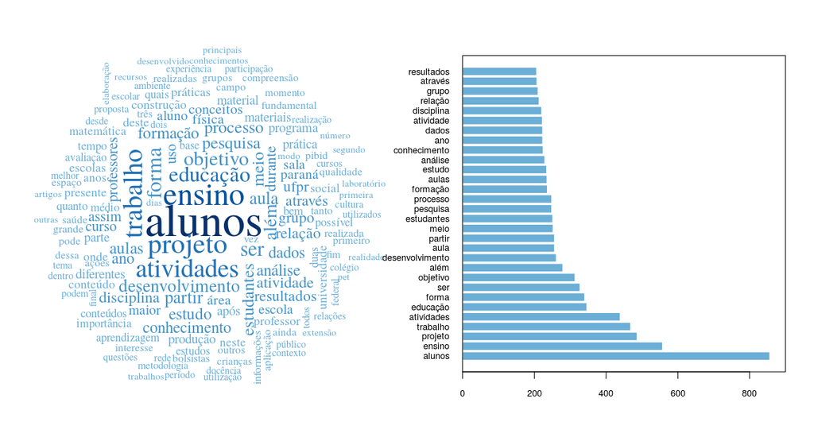

Figura 1: 1% das palavras mais frequentes (esquerda), frequências dos 30 termos com mais ocorrência (à direita)

```r
# Frequência dos termos da matriz termo-documento
counts <- rowSums(ma)

# Ponto de corte das palavras 1% mais frequentes
corte <- quantile(counts, probs = 0.99)

# Wordcloud das palavras
paleta <- brewer.pal(9, "Blues")[-(1:4)]

par(mfrow = c(1, 2))
wordcloud(words = names(counts)[counts > corte],
          freq = counts[counts > corte],
          random.order = F,
          colors = paleta,
          family = "serif")

barplot(sort(rowSums(ma), decreasing = TRUE)[1:30],
        las = 1,
        cex.axis = 0.8,
        cex.names = 0.8,
        horiz = TRUE,
        col = "#6BAED6", border = "white",
        xlim = c(0, 900))
box()
```

Nota-se pela figura 1, que essencialmente os trabalhos apresentados na SIEPE referem-se a alunos, projeto, ensino, trabalho, conforme visto nos gráficos da figura 1.

Conforme dito anteriormente, os trabalhos apresentados são agrupados por área temática. A seguir, tem-se uma nuvem de palavras para cada área selecionada pela comissão organizadora da SIEPE. Em todas as nuvens são exibidas as 100 palavras mais frequentes.

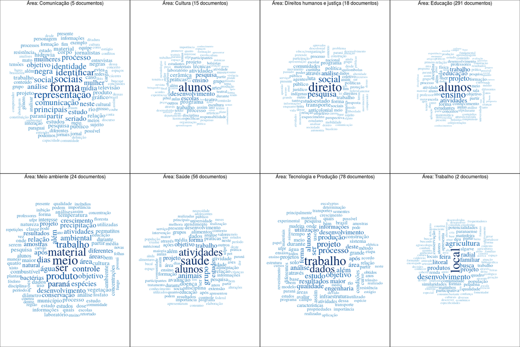

Figura 2: Wordcloud das áreas temáticas selecionadas pela SIEPE

```r
# Renomeando as áreas temáticas
nareas <- c("Comunicação", "Cultura", "Direitos humanos e justiça",
            "Educação", "Meio ambiente", "Saúde", "Tecnologia e Produção",
            "Trabalho")

grupos_siepe <- rep(seq(length(textos)), sapply(textos, length))

par(mfrow = c(2, 4), mar = c(0, 0, 0, 0))
sapply(seq(length(textos)), function(i) {
    index <- grupos_siepe == i
    ma <- ma[, index]
    # Frequência dos termos da matriz termo-documento
    freqs <- sort(rowSums(ma), decreasing = TRUE)[1:100]
    # Wordcloud das palavras
    paleta <- brewer.pal(9, "Blues")[-(1:4)]
    wordcloud(words = names(freqs),
              freq = freqs,
              min.freq = 1,
              random.order = F,
              colors = paleta,
              family = "serif")
    ndocs <- sapply(textos, length)[i]
    main <- paste0("Área: ", nareas[i], " (", ndocs, " documentos", ")")
    mtext(main, line = -1.5)
    box()
})
```

Nota-se pela figura 2, que para diversas áreas os resumos contém um conjunto de palavras similares, indicando que a separação realizada pela organização do evento não é efetiva. Por exemplo, nas áreas **cultura**, **educação** e **saúde** que a palavra *aluno* faz parte daquelas mais frequentes. Por esta razão, não utilizou-se as áreas pré definidas pela SIEPE para fazer o agrupamento dos resumos.

## Resultados

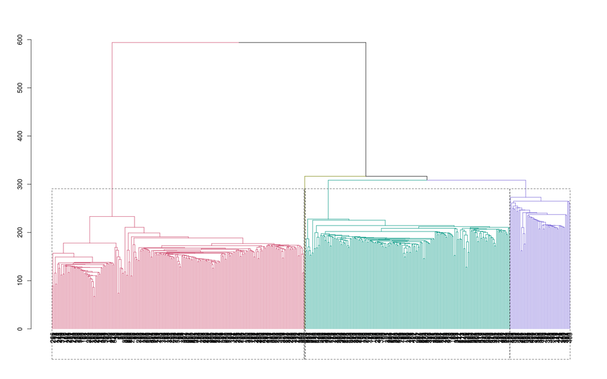

Figura 3: Dendograma dos resumos

```r
# Definindo o número de grupos pelo método hierárquico

# Matriz de distâncias euclidiana
mdist <- dist(scale(t(ma)))

# Agrupamento hierárquico
agroup <- hclust(mdist, method = "ward.D")

# Exibe o dendograma
dgroup <- as.dendrogram(agroup)
dgroup %>% color_branches(k = 4) %>% plot(horiz = FALSE)
dgroup %>% rect.dendrogram(k = 4, horiz = FALSE, lty = 2,
                          border = "gray30")
```

Na figura 3, tem-se o gráfico das distâncias para cada documento. A linha em pontilhado representa o ponto de corte para a vizualização dos grupos e com isso, os resumos formaram quatro grupos, os quais são representados pelas cores.  
O agrupamento foi relizado com o método não hierárquico k-means. Como agrupamentos não hierárquicos necessitam que o número de grupos a serem formados seja conhecido, a quantidade de grupos selecionada pela figura 3 é utilizada para fazer o agrupamento.  
Para permitir a interpretação dos grupos, exibi-se na figura 4 os 100 termos mais frequentes em cada grupo.

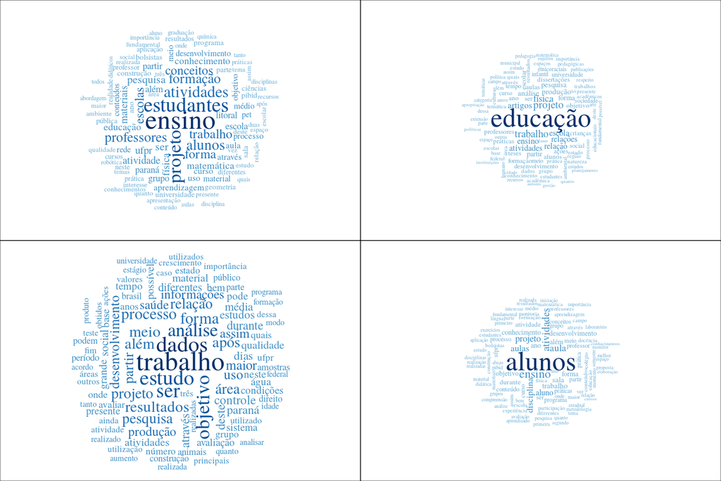

Figura 4: Wordcloud do resultado do agrupamento

```r
# Agrupamento não hierárquico (k-means)

# agrupa os documentos
kms <- kmeans(x = t(ma), centers = 4,
              iter.max = 50, nstart = 10)

## Wordclouds
par(mfrow = c(2, 2), mar = c(0, 0, 0, 0))
sapply(seq(unique(kms$cluster)), function(i) {
    index <- kms$cluster == i
    ma <- ma[, index]
    # Frequência dos termos da matriz termo-documento
    freqs1 <- sort(rowSums(ma), decreasing = TRUE)[1:100]
    # Wordcloud das palavras
    paleta <- brewer.pal(9, "Blues")[-(1:4)]
    wordcloud(words = names(freqs1),
              freq = freqs1,
              random.order = F,
              colors = paleta,
              family = "serif")
    box()
})
```

A partir da figura 4 pode-se caracterizar os grupos:

**Grupo 1:** trabalhos essencialmente sobre ensino;  
**Grupo 2:** trabalhos essencialmente sobre educação;  
**Grupo 3:** trabalhos essencialmente sobre trabalho;  
**Grupo 4:** trabalhos essencialmente sobre alunos;